# scFM: Bayesian segmented Gaussian copula factor model for single-cell sequencing data

Junsouk Choi

# Introduction

The `scFM` package implements an efficient data-augmented Gibbs sampler for the Bayesian segmented Gaussian copula factor model (scFM) developed by Choi et el. (2025+). The scFM model directly addresses both the inflation of low counts and the high skewness observed in single-cell sequencing data by incorporating a segmentation procedure within the copula framework.

In this vignette, we provide a tutorial on how to use the core functionalities of the `scFM` package.

# LCL Data

This vignette utilizes the LCL dataset, which is provided as a built-in dataset in the `scFM` package. The LCL dataset was used for real data application of scFM in Choi et el. (2025+). It consists of $n=5,135$ high-quality cells with the top $p=100$ most variable genes, selected after pre-processing the original set of 7,247 cells from lymphoblastoid cell line (LCL) GM12878, which was initially sequenced for 18,170 genes. In this vignette, we reproduce the analysis presented in Section 5 of Choi et al. (2025+).

```r
# load necessary packages including scFM
library(scFM)
library(GIGrvg)
library(statmod)
library(ggplot2)
library(tibble)
library(SingleR)
library(celldex)

# set random seed
set.seed(7)

# load the built-in LCL dataset
data(LCL)
x = LCL
dim(x)  # check dimensions of the dataset
[1] 5135  100
```

# Using `scFM` to Analyze the LCL Dataset

## Hyperparameter Configuration

To fit the scFM model to the LCL dataset, we first need to specify its hyperparameters. We set the maximum number of latent factors to $k_{max} = 8$, and select a threshold of $m = 1$ that distinguishes inflated low counts from typical higher counts in single-cell data. See Choi et al. (2025+) for further details on the choice of these two hyperparameters. In addition to $k_{max}$ and $m$, scFM includes two other hyperparameters: $(a_\sigma, b_\sigma)$ for the inverse-gamma prior on the error variances (specified by the tag `Sigma`), and $\alpha$ for the column-wise Dirichlet-Laplace prior on the factor loadings matrix (specified by the tag `phi`). By default, we use $\alpha = 0.5$ and $a_\sigma = b_\sigma = 0.1$, corresponding to non-informative priors.

```r
# set k_{max} and m
k = 8
m = 1

# set hyperparameters for priors
priors = list()
priors$Sigma = c(0.1, 0.1)
priors$phi = 0.5
```

## MCMC Initialization

To run the data-augmented Gibbs sampler for scFM, we should also initialize the model parameters for MCMC. We initialize the latent Gaussian $\mathbf{Z}$ using the scaled empirical CDF of each variable in the data. The parameter $\boldsymbol{\delta}$ can be initialized based on the proportion of low counts considered inflated (here, 0 and 1, since $m = 1$).

```r
# initialize parameters Z and delta
starting = list()
n = nrow(x)
p = ncol(x)
ecdf.scale = n/(n + 1)
eFx = apply(x, 2, ecdf)
eFx = lapply(eFx, function(x) {
    function(y) ecdf.scale * x(y)
})
eFxx = Map(function(f, x) do.call(f, list(x)), eFx, plyr::alply(x,
    2))
starting$Z = matrix(unlist(lapply(eFxx, function(pr) qnorm(pr))),
    n, p)
starting$delta = matrix(0, p, m + 1)
for (d in 0:m) {
    starting$delta[, d + 1] = qnorm(colMeans(x <= d))
}
```

We initialize the factor loadings and scores by performing standard factor analysis on the latent $\mathbf{Z}$ initialized above.

```r
# initialize Lambda and U using standard factor analysis
out0 = factanal(starting$Z, factors = k, scores = "regression")
starting$Lambda = as.matrix(out0$loadings)
starting$U = out0$scores
```

The remaining parameters $\boldsymbol{\Sigma}$, $\phi$, $\tau$, and $\boldsymbol{\Xi}$ are initialized by performing a short Gibbs sampling run, conditional on the values obtained for the other parameters above.

```r
# initialize Sigma, phi, tau, and Xi via a short Gibbs
# sampling
Sigma = diag(1, p)
phi = rep(1/k, k)
tau = 1
Xi = matrix(rexp(p * k, rate = 0.5), p, k)

for (iter in 1:1000) {
    Sigma[diag(rep(TRUE, p))] = 1/rgamma(p, shape = priors$Sigma[1] +
        rep(n/2, p), rate = priors$Sigma[2] + 0.5 * colSums((starting$Z -
        tcrossprod(starting$U, starting$Lambda))^2))

    H = rep(NA, k)
    for (l in 1:k) {
        H[l] = rgig(1, lambda = priors$phi - p, chi = 2 * sum(abs(starting$Lambda[,
            l])), psi = 1)
    }
    phi = H/sum(H)
    tau = rgig(1, lambda = k * (priors$phi - p), chi = 2 * sum(t(abs(starting$Lambda))/phi),
        psi = 1)
    Xi_tilde = rinvgauss(p * k, mean = c(t(phi * t(tau/abs(starting$Lambda)))))
    Xi = matrix(1/Xi_tilde, p, k)
}

starting$Sigma = Sigma
starting$phi = phi
starting$tau = tau
starting$Xi = Xi
```

## Data-augmented Gibbs Sampling for scFM

We are now ready to run the data-augmented Gibbs sampler for the scFM model using the `gibbs_scFM` function from the `scFM` package. This function produces MCMC samples of the latent factor loadings ($\boldsymbol{\Lambda}$) and factor scores ($\mathbf{U}$), which are labeled as `Lambda` and `U`, respectively. Note that this process may take a few hours to complete. After the Gibbs sampler completes, one can compute the posterior mean of the factor scores using the resulting MCMC samples.

```r
# run the data-augmented Gibbs sampling for scFM
nmcmc = 10000
nburnin = 5000
out = gibbs_scFM(x, k, m = 1, starting, priors, nmcmc = nmcmc,
    nburnin = nburnin)
iter = 500
iter = 1000
iter = 1500
iter = 2000
iter = 2500
iter = 3000
iter = 3500
iter = 4000
iter = 4500
iter = 5000
iter = 5500
iter = 6000
iter = 6500
iter = 7000
iter = 7500
iter = 8000
iter = 8500
iter = 9000
iter = 9500
iter = 10000

# compute posterior means of the factor loadings and scores
loading_est = apply(out$Lambda, c(1, 2), mean)
score_est = apply(out$U, c(1, 2), mean)
```

## Selection of Significant Latent Factors

In scFM, the number of significant latent factors is determined via the column-wise Dirichlet-Laplace prior on the factor loadings matrix $\boldsymbol{\Lambda}$. Posterior inference on the number of significant factors is performed by applying k-means clustering to the columns of each MCMC asmple of $\boldsymbol{\Lambda}$, dividing them into two clusters: one representing significant loadings and the other representing near-zero loadings. For each MCMC sample, the number of significant factors is defined by the size of the cluster whose loadings exhibit greater deviation from zero. The final estimate of the number of significant latent factors, denoted as $\hat{k}$, is obtained by taking the mode across all samples. After estimating $\hat{k}$, we identify the corresponding significant factors by selecting the $\hat{k}$ columns of the posterior mean of $\boldsymbol{\Lambda}$ that have the largest $\ell_2$-norms.

```r
# infer the number of significant latent factors
sig_facto = matrix(0, dim(out$Lambda)[2], dim(out$Lambda)[3])
for (i in 1:dim(out$Lambda)[3]) {
    kmeans_lambda = kmeans(t(out$Lambda[, , i]), centers = 2,
        nstart = 10)
    sig_facto[which(kmeans_lambda$cluster == which.max(rowSums(kmeans_lambda$centers^2))),
        i] = 1
}

table(colSums(sig_facto))  # indicates the existence of two significant latent factors

   2
5000

# select the significant latent factors
sqrt(colSums(loading_est^2))  # the first two factors show the largest L2-norm
[1] 4.149778 3.980186 1.512326 1.544723 1.207097 1.522789 1.265229 1.369179
score_est = score_est[, 1:2]
```

The scFM model ensures the identifiability of factor loadings (up to permutation and sign flip), enabling meaningful and reproducible interpretation of the latent factors. To interpret the significant latent factors, we examine the absolute values of their loadings to identify the most associated genes. Factor 1 exhibits large absolute loadings for genes strongly related to cell cycling, while Factor 2 shows high loadings for genes involved in immune functions. Accordingly, we interpret Factors 1 and 2 as representing cell cycle and immune function activity, respectively. Further details on the interpretation of the identified factors are provided in Section 5.2 of Choi et al. (2025+).

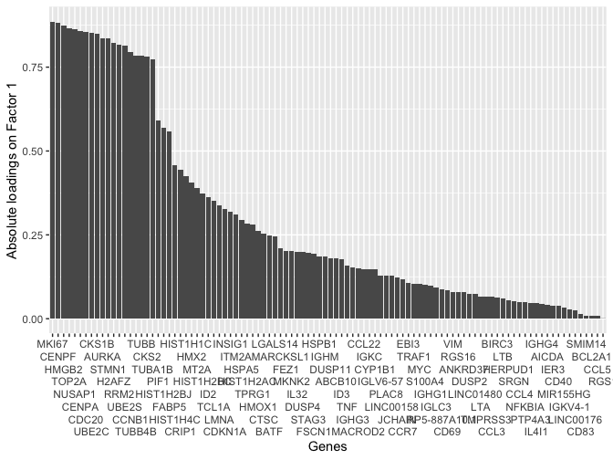

```r
# display absolute values of the estimated factor loadings
# on the significant factors
rownames(loading_est) = colnames(x)

order1 = order(abs(loading_est[, 1]), decreasing = TRUE)
df = data.frame(gene = factor(colnames(x), levels = colnames(x)[order1]),
    value = abs(loading_est[, 1]))
loading1 = ggplot(df, aes(x = gene, y = value)) + geom_bar(stat = "identity") +
    scale_x_discrete(guide = guide_axis(n.dodge = 8)) + labs(x = "Genes",
    y = "Absolute loadings on Factor 1")
loading1
```

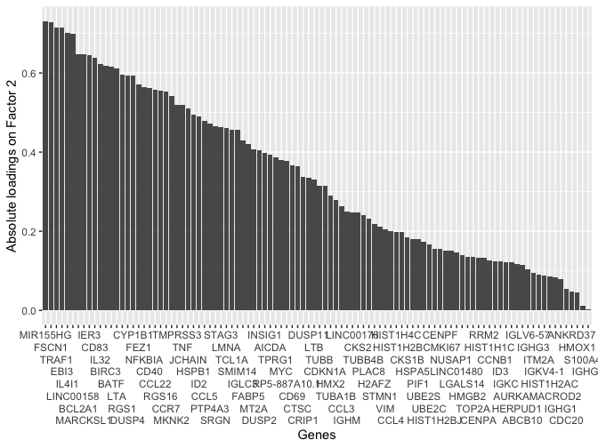

```r
order2 = order(abs(loading_est[, 2]), decreasing = TRUE)
df = data.frame(gene = factor(colnames(x), levels = colnames(x)[order2]),
    value = abs(loading_est[, 2]))
loading2 = ggplot(df, aes(x = gene, y = value)) + geom_bar(stat = "identity") +
    scale_x_discrete(guide = guide_axis(n.dodge = 8)) + labs(x = "Genes",
    y = "Absolute loadings on Factor 2")
loading2
```

```r
# check genes with the 10 largest abosolute loadings for
# each significant factor
sort(loading_est[rank(abs(loading_est[, 1])) > 90, 1], decreasing = TRUE)
    MKI67     CENPF     HMGB2     TOP2A    NUSAP1     CENPA     CDC20     UBE2C
0.8860024 0.8819128 0.8726863 0.8658217 0.8641594 0.8576116 0.8540322 0.8521866
    CKS1B     AURKA
0.8490072 0.8359620
sort(loading_est[rank(abs(loading_est[, 2])) > 90, 2], decreasing = TRUE)
 MIR155HG     FSCN1     TRAF1      EBI3     IL4I1 LINC00158    BCL2A1  MARCKSL1
0.7313799 0.7278093 0.7157463 0.7148770 0.7017290 0.6986787 0.6471848 0.6463616
     IER3      CD83
0.6444790 0.6391969
```